# Estatística espacial - Dados de Área

Lista de Exercícios 8

Elisa Fink, Geanine Henriques, Giovanna Vidor, Vinícius Zaltron e Vitor Cunha

2023

# Essa lista pode ser feita em grupos de ATÉ 7 pessoas.

## O alun@ ou grupo deverá apresentar o código da anáise no dia 14 de abril. 50% da nota é o código (crie uma pasta no github) e 50% da nota é a apresentação (15 minutos)

```r
library(sf)
library(spdep)
library(tmap)
library(ggplot2)
library(INLA)
library(geosphere)
library(spBayes)
```

## Questão 1

Escolha uma base de dados de área e faça as seguintes análises:

### a) Comente sobre a escolha da base e qual a variável de interesse.

para a base de dados escolhemos a base “nc” do pacote sf, que contém dados sobre a contagem de nascimentos e mortalidade infantil dos condados da Carolina do Norte, de 01/07/1974 a 30/06/1978 e de 01/07/1979 a 30/06/1984. A nossa variável de interesse será a mortalidade infantil em termos relativos no ano de 1974.

```r
# banco de dados
nc <- st_read(system.file("shape/nc.shp", package="sf"))
```

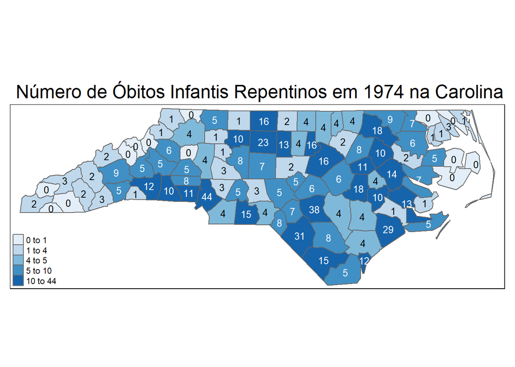

```r
mapa <- tm_shape(nc) +
  tm_polygons("SID74", palette="Blues", style="quantile") +
  tm_layout(main.title = "Número de Óbitos Infantis Repentinos em 1974 na Carolina do Norte", legend.position=c("LEFT", "BOTTOM"), legend.title.size = 0.001) +
  tm_text("SID74", size = 0.8, root = 1)
mapa
```

### b) Calcule a proporção da variável de interesse.

Para a proporção da mortalidade infantil, calculamos a divisão entre o número total de óbitos e o número total de nascimentos por condado.

```r
nc$taxa <- round((nc$SID74/nc$BIR74),3)
nc$taxa
```

```
##   [1] 0.001 0.000 0.002 0.002 0.006 0.005 0.000 0.000 0.004 0.001 0.002 0.004
##  [13] 0.002 0.003 0.002 0.005 0.002 0.001 0.001 0.002 0.001 0.000 0.001 0.001
##  [25] 0.001 0.001 0.003 0.005 0.001 0.002 0.002 0.000 0.003 0.002 0.000 0.001
##  [37] 0.001 0.003 0.001 0.001 0.000 0.001 0.001 0.005 0.000 0.003 0.002 0.001
##  [49] 0.003 0.001 0.003 0.001 0.001 0.002 0.001 0.000 0.003 0.004 0.005 0.002
##  [61] 0.004 0.003 0.002 0.002 0.004 0.002 0.002 0.002 0.001 0.002 0.002 0.002
##  [73] 0.000 0.003 0.003 0.001 0.002 0.000 0.001 0.002 0.002 0.002 0.002 0.001
##  [85] 0.010 0.005 0.000 0.002 0.001 0.000 0.002 0.004 0.003 0.004 0.002 0.004
##  [97] 0.003 0.004 0.002 0.002
```

Ainda, se quisermos uma proporção geral, podemos dividir o total de óbitos pelo total do número de nascimentos sem a especificação por condados.

```r
round((sum(nc$SID74))/(sum(nc$BIR74)),3)
```

```
## [1] 0.002
```

### c) Faça um mapa da taxa, calcule a SMR e faça um gráfico de dispersão considerando essas taxas e o tamanho da população.

Mapa da taxa que calculamos anteriormente:

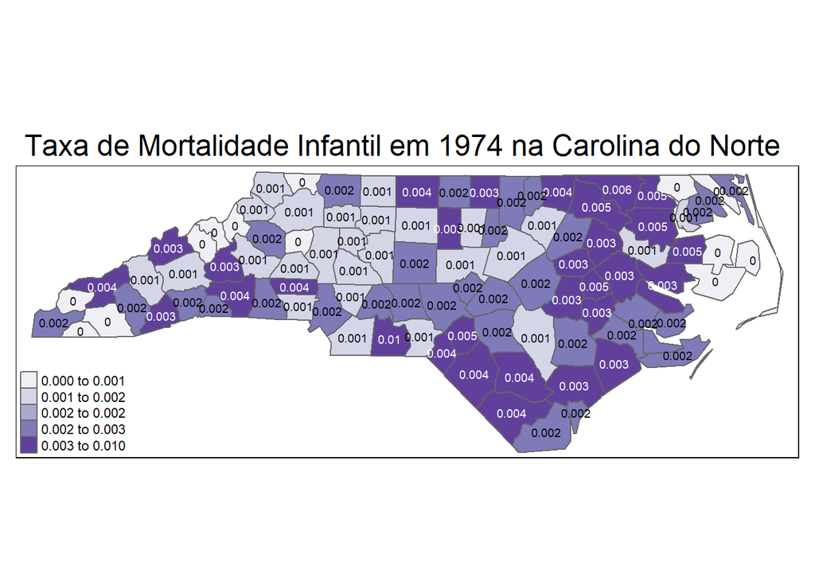

```r
mapa_prop <- tm_shape(nc) +
  tm_polygons("taxa", palette="Purples", style="quantile") +
  tm_layout(main.title = "Taxa de Mortalidade Infantil em 1974 na Carolina do Norte", legend.position=c("LEFT", "BOTTOM"), legend.title.size = 0.001) +
  tm_text("taxa", size = 0.6, root = 1)
mapa_prop
```

Para a SMR, teremos o resultado para cada condado seguindo a ordem das operações segundo o script abaixo:

```r
exp <- sum(nc$SID74)/sum(nc$BIR74)
nc$exp <- nc$BIR74*exp
nc$smr <- nc$SID74/nc$exp
head(nc$smr)
```

```
## [1] 0.4534332 0.0000000 0.7758715 0.9738103 3.1331885 2.3848964
```

Gráfico de dispersão:

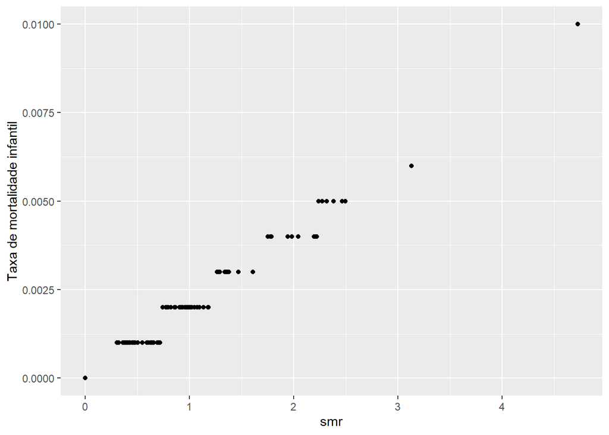

```r
ggplot(nc, aes(x=smr, y=taxa)) +
geom_point() +
labs(x="smr", y="Taxa de mortalidade infantil")
```

Como há uma relação aproximadamente linear entre os SMRs para cada condado e a sua respectiva taxa de mortalidade infantil, podemos constatar que para esse cenário a estimativa de SMR é não-viesada.

### d) Calcule o índice de moran para esses dados.

```r
map <- as_Spatial(st_zm(nc))
nb <- poly2nb(map)
w <- nb2listw(nb, style="W")

lw <- nb2listw(nb, style="W", zero.policy=TRUE)
#exemplo pesos
lw$weights[1]
```

```
## [[1]]
## [1] 0.3333333 0.3333333 0.3333333
```

```r
#analitica
I <- moran(map$SID74, lw, length(nb), Szero(lw), NAOK = TRUE)[1]
I
```

```
## $I
## [1] 0.1477405
```

```r
#monte carlo
MC<- moran.mc(map$SID74, lw, nsim=300, alternative="greater",zero.policy=TRUE, adjust.n=FALSE )
MC
```

```
##
##  Monte-Carlo simulation of Moran I
##
## data:  map$SID74
## weights: lw
## number of simulations + 1: 301
##
## statistic = 0.14774, observed rank = 295, p-value = 0.01993
## alternative hypothesis: greater
```

O coeficiente de Moran mede a autocorrelação espacial global. No nosso caso, comparando com dados gerados pelo procedimento de Monte-Carlo, o teste foi significativo, já que p < 0.05. Ainda assim, é uma autocorrelação global positiva fraca, uma vez que o índice foi estimado em aproximadamente 0.148.

### e) Calcule o risco relativo um modelo sem efeito aleatório espacial.

```r
modelo <- glm(SID74 ~ BIR74,
              data=nc, family=poisson)

print("Coeficientes do modelo (OR):")
```

```
## [1] "Coeficientes do modelo (OR):"
```

```r
exp(cbind(OR = coef(modelo), confint(modelo)))
```

```
##                   OR    2.5 %   97.5 %
## (Intercept) 3.644591 3.270402 4.049978
## BIR74       1.000126 1.000115 1.000136
```

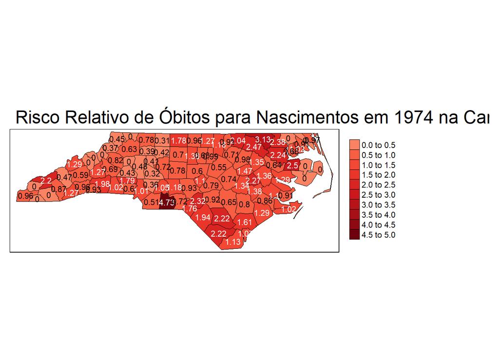

```r
pmap <- probmap(nc$SID74, nc$BIR74)
pmap$relRisk <- round(pmap$relRisk, 0)
pmap$relRisk <- pmap$relRisk/100
nc$pmap <- pmap$pmap
nc$relRisk <- pmap$relRisk
brks <- seq(0,5,0.5)
tm_shape(nc) +
  tm_fill("relRisk", breaks=brks, midpoint=0.5, palette="Reds", strech.palette = F) +
  tm_layout(legend.outside=TRUE, legend.title.size = 0.01, main.title = "Risco Relativo de Óbitos para Nascimentos em 1974 na Carolina do Norte") +
  tm_text("relRisk", size = 0.7, root = 1) +
  tm_borders(col = "black", lwd = 0.1)
```

### f) Calcule o risco relativo utilizando o modelo BYM2, utilize alguma covariável.

Apesar de não ser um procedimento trivial, fica como desafio ao leitor.

### g) Interprete os parâmetros estimados do modelo da letra *e*.

O coeficiente de Odds Ratio apresentado em si não faz muito sentido, uma vez que estamos modelando o número de óbitos em função do número de nascimentos, mas colocando em perspectiva o mapa com as Odds Ratios para cada condado, significa a chance de que haja o óbito dado que houve nascimento naquele condado versus a chance de que haja um óbito dado que o nascimento não ocorreu naquele condado. Essa linha de raciocínio, embora pouco usual, tem sentido prático. Os condados com OR > 1 são tipicamente os condados com taxa de mortalidade infantil maior do que a taxa de mortalidade infantil geral, e os condados com OR < 1 são tipicamente os condados com taxa de mortalidade infantil menor do que a taxa de mortalidade infantil geral.

### h) Qual a diferença entre as taxas do modelo bayesiano e a SMR?